# primera_tarea

ProfesorX

2023-04-05

#MEDIDAS DE RESUMEN

Para ilustrar el cálculo de las mediadas de resumen, vamos a generar 250 datos aleatorios, normalmente distribuidos con una media de $\mu=3$ y una desviación estándar de $\sigma=5$

```r
X=rnorm(250,mean=3,sd=5)
```

##MEDIDAS DE TENDENCIA CENTRAL

###MEDIA Para calcular la media, utilizamos la función mean:

```r
mediaX=mean(X)
mediaX
```

```
## [1] 2.896717
```

Esto nos lleva a un valor de 2.8967171

###MEDIANA La mediana la calculamos con la función median:

```r
medianaX=median(X)
medianaX
```

```
## [1] 2.556022
```

Esto nos lleva a un valor de mediana de 2.556022.

###MODA La moda la calculamos con la función mfv:

```r
modaX=mfv(X)
modaX
```

[output not shown]

[output cut: 27 more lines]

##Mínimo

Se calcula el mínimo en un objeto llamado minimoX:

```r
minimoX=min(X)
```

##Máximo

Se calcula el máximo en un objeto llamado maximoX:

```r
maximoX=max(X)
```

##Rango

Se calcula el rango en un objeto llamado rangoX:

```r
rangoX=maximoX-minimoX
```

###Se imprimen los valores de mínimo, máximo y rango en la pantalla:

```r
minimoX
```

```
## [1] -9.434797
```

```r
maximoX
```

```
## [1] 19.67639
```

```r
rangoX
```

```
## [1] 29.11119
```

### Calcular el número de intervalos utilizando la regla de Sturges

```r
n=length(X)
k=ceiling(log2(n)+1)
k
```

```
## [1] 9
```

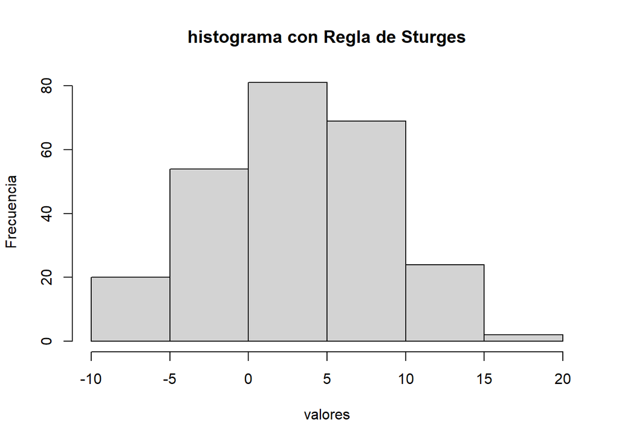

```r
hist(X,breaks = k,main = "histograma con Regla de Sturges",
     xlab="valores",ylab ="Frecuencia")
```

###AMPLITUD DE LOS INTERVALOS (h): La amplitud de los intervalos se puede calcular dividiendo el rango (r) entre el número de intervalos (k):

```r
h=rangoX/k
h
```

```
## [1] 3.234576
```

### Definir intervalos

```r
intervalos=seq(minimoX,maximoX, by=h)
intervalos
```

```
##  [1] -9.4347973 -6.2002211 -2.9656449  0.2689314  3.5035076  6.7380838
##  [7]  9.9726601 13.2072363 16.4418125 19.6763887
```

### Crear tabla de frecuencia

```r
frecuenciasX=cut(X,breaks = intervalos, include.lowest = TRUE, right = FALSE)
frecuenciasX
```

```
##   [1] [3.5,6.74)    [-2.97,0.269) [0.269,3.5)   [9.97,13.2)   [-2.97,0.269)
##   [6] [9.97,13.2)   [3.5,6.74)    [-2.97,0.269) [9.97,13.2)   [3.5,6.74)
##  [11] [0.269,3.5)   [-9.43,-6.2)  [0.269,3.5)   [-9.43,-6.2)  [-6.2,-2.97)
##  [16] [0.269,3.5)   [-2.97,0.269) [3.5,6.74)    [0.269,3.5)   [6.74,9.97)
##  [21] [9.97,13.2)   [3.5,6.74)    [0.269,3.5)   [0.269,3.5)   [0.269,3.5)
##  [26] [3.5,6.74)    [0.269,3.5)   [0.269,3.5)   [-2.97,0.269) [-2.97,0.269)
##  [31] [6.74,9.97)   [3.5,6.74)    [-9.43,-6.2)  [0.269,3.5)   [0.269,3.5)
##  [36] [3.5,6.74)    [9.97,13.2)   [-2.97,0.269) [-6.2,-2.97)  [-6.2,-2.97)
##  [41] [0.269,3.5)   [0.269,3.5)   [0.269,3.5)   [6.74,9.97)   [3.5,6.74)
##  [46] [6.74,9.97)   [3.5,6.74)    [6.74,9.97)   [-2.97,0.269) [-2.97,0.269)
##  [51] [0.269,3.5)   [-2.97,0.269) [0.269,3.5)   [6.74,9.97)   [-2.97,0.269)
##  [56] [-2.97,0.269) [0.269,3.5)   [0.269,3.5)   [3.5,6.74)    [0.269,3.5)
##  [61] [3.5,6.74)    [0.269,3.5)   [6.74,9.97)   [3.5,6.74)    [6.74,9.97)
##  [66] [9.97,13.2)   [6.74,9.97)   [-6.2,-2.97)  [6.74,9.97)   [0.269,3.5)
##  [71] [6.74,9.97)   [0.269,3.5)   [6.74,9.97)   [-9.43,-6.2)  [-9.43,-6.2)
```

[output cut: 36 more lines]

### Contar frecuencias por intervalo

```r
Tabla_frecuenciaX=table(frecuenciasX)
Tabla_frecuenciaX
```

```
## frecuenciasX
##  [-9.43,-6.2)  [-6.2,-2.97) [-2.97,0.269)   [0.269,3.5)    [3.5,6.74)
##            14            21            42            60            56
##   [6.74,9.97)   [9.97,13.2)   [13.2,16.4)   [16.4,19.7]
##            31            21             4             1
```

###Calcular la frecuencia acumulada

```r
frecuencia_acumuladaX= cumsum(Tabla_frecuenciaX)
frecuencia_acumuladaX
```

```
##  [-9.43,-6.2)  [-6.2,-2.97) [-2.97,0.269)   [0.269,3.5)    [3.5,6.74)
##            14            35            77           137           193
##   [6.74,9.97)   [9.97,13.2)   [13.2,16.4)   [16.4,19.7]
##           224           245           249           250
```

### Calcular marcas de clase

```r
marcas_claseX=((intervalos+(intervalos+h))/2)
marcas_claseX
```

```
##  [1] -7.817509 -4.582933 -1.348357  1.886219  5.120796  8.355372 11.589948
##  [8] 14.824524 18.059101 21.293677
```

# Mostrar tabla de frecuencia por intervalos

```
## Intervalo        Marca de Clase  Frecuencia  Frecuencia Acumulada
```

```
## -9.43 - -6.20        -7.82       14      14
## -6.20 - -2.97        -4.58       21      35
## -2.97 - 0.27     -1.35       42      77
## 0.27 - 3.50      1.89        60      137
## 3.50 - 6.74      5.12        56      193
## 6.74 - 9.97      8.36        31      224
## 9.97 - 13.21     11.59       21      245
## 13.21 - 16.44        14.82       4       249
## 16.44 - 19.68        18.06       1       250
```

###cuartiles

```r
intervalos <- seq(minimoX, maximoX, by = h)
limites_inferiores= intervalos[-length(intervalos)]
limites_superiores= intervalos[-1]
letras <- LETTERS[1:length(limites_inferiores)]
variable_categorica <- cut(X, breaks = intervalos, right = FALSE, labels = letras)

for (i in 1:length(limites_inferiores)) {
  nombre_inferior <- paste("limite_inferior", letras[i], sep = "_")
  assign(nombre_inferior, limites_inferiores[i])

  nombre_superior <- paste("limite_superior", letras[i], sep = "_")
  assign(nombre_superior, limites_superiores[i])
}
```

```r
#Posición de los cuartiles
# Calcular la posición del primer cuartil
n=250
k1=1
Q1=(k1*n/4)
Q1
```

```
## [1] 62.5
```

```r
# [1] 25

# Calcular la posición del segundo cuartil (mediana)
k2=2
Q2=(k2*n/4)
Q2
```

```
## [1] 125
```

```r
# [2] 50

# Calcular la posición del tercer cuartil
k3=3
Q3=(k3*n/4)
Q3
```

```
## [1] 187.5
```

```r
# [3] 75
```

```r
rango_intercuartílico=Q3-Q1
rango_intercuartílico
```

```
## [1] 125
```

```r
# Calcular la varianza
varianza= var(X)

# Calcular la desviación estándar
desviaciónestándar=sd(X)

# Calcular la media muestral
media1 <- mean(X)

#Calcular la desviación media absoluta
dmaR=mad(X)

varianza
```

```
## [1] 28.69357
```

```r
desviaciónestándar
```

```
## [1] 5.356638
```

```r
media1
```

```
## [1] 2.896717
```

```r
dmaR
```

```
## [1] 5.381617
```

##MEDIDAS DE FORMA

```r
library(e1071)
#Calculando la asimetría
asimetría=skewness(X)

# Calcular la curtosis
curtosis=kurtosis(X)

#Calculando los grados de libertad

grados_de_libertad=n-1

#Calculando los valores estándar Zi

zi= qnorm(0.975)



asimetría
```

```
## [1] 0.09394454
```

```r
curtosis
```

```
## [1] -0.3324908
```

```r
grados_de_libertad
```

```
## [1] 249
```

```r
zi
```

```
## [1] 1.959964
```

```r
proporcion <- sum(abs(X - medianaX) <= 2*desviaciónestándar) / length(X)
k3= 2
# número de desviaciones estándar
limite_inferior= 1 - 1/k^2
if (proporcion >= limite_inferior) {
  print("El teorema de Chebyshev se cumple para k3 = 2.")
} else {
  print("El teorema de Chebyshev no se cumple para k3 = 2.")
}
```

[output not shown]